# Lab 7 — Confidence Intervals & One-Sample t-test

Quantitative Reasoning · LAB 413

Instructor: Subin Na

October 22, 2025

> **How to use this document.** Run the code along with me. Comments start with `#`. Each section mirrors the live lab; code chunks show the command and its output together.

**Today’s plan**

1. Clean environment + setup
2. Import & understand College data
3. Prepare variables (coercion)
4. CI + one-sample *t*-test for `UGradPerThou` ($\mu = 55$)
5. CI + one-sample *t*-test for `Undergrads`
6. Quick practice
7. Wrap-up

# 1 Clean Environment + Setup

```r
rm(list = ls())   # clean environment

# Load the packages
library(dplyr)
library(ggplot2)
library(stats)
```

> In the live session we set the working directory with `setwd(...)`. In this document the data file `Collegedata.csv` sits next to the `.Rmd`, so no `setwd()` is needed.

# 2 Import & Understand College Data

```r
college <- read.csv("Collegedata.csv")

# In RStudio you would run View(college); here we preview the first rows.
knitr::kable(head(college), caption = "First rows of the College data")
```

First rows of the College data

| State | Undergrads | Population | UGradPerThou |
| --- | --- | --- | --- |
| New Jersey | 326358 | 8640218 | 37.77196 |
| Nevada | 100760 | 2484196 | 40.56041 |
| Alaska | 27463 | 676301 | 40.60766 |
| Georgia | 378947 | 9318715 | 40.66516 |
| Connecticut | 142926 | 3487896 | 40.97771 |
| Tennessee | 250974 | 6068306 | 41.35816 |

# 3 Prepare Variables (Coercion)

**Variable types in R**

1. **Numeric** (`num`): numbers with decimals
2. **Integer** (`int`): whole numbers (add `L` to force integer)
3. **Character** (`chr`): text / string values
4. **Factor**: categorical variables (stored as integers with labels)

```r
name <- "Subin"
class(name)     # "character"
```

```
#> [1] "character"
```

```r
gender <- factor(c("Male", "Female", "Male"))
class(gender)   # "factor"
```

```
#> [1] "factor"
```

```r
levels(gender)  # "Female" "Male"
```

```
#> [1] "Female" "Male"
```

```r
# Make sure numeric (coercion turns non-numeric values into NA)
college$UGradPerThou <- as.numeric(college$UGradPerThou)
college$Undergrads   <- as.numeric(college$Undergrads)

# Quick check
summary(college$UGradPerThou)
```

```
#>    Min. 1st Qu.  Median    Mean 3rd Qu.    Max.
#>   37.77   45.73   49.43   51.45   54.46   77.13
```

```r
summary(college$Undergrads)
```

```
#>    Min. 1st Qu.  Median    Mean 3rd Qu.    Max.
#>   27463   90659  203641  302136  333223 2172354
```

# 4 CI & t-test for `UGradPerThou` ($\mu = 55$)

**Step 1 — Point estimate (sample mean).**

```r
mean(college$UGradPerThou, na.rm = TRUE)
```

```
#> [1] 51.45116
```

**Step 2 — One-sample *t*-test** (test whether the mean equals 55).

```r
t.test(college$UGradPerThou, mu = 55)
```

```
#>
#>  One Sample t-test
#>
#> data:  college$UGradPerThou
#> t = -2.856, df = 49, p-value = 0.006276
#> alternative hypothesis: true mean is not equal to 55
#> 95 percent confidence interval:
#>  48.95411 53.94821
#> sample estimates:
#> mean of x
#>  51.45116
```

**Step 3 — Extract the 95% CI bounds** (for plotting).

```r
ci_ugpt <- t.test(college$UGradPerThou, conf.level = 0.95)$conf.int
ci_ugpt   # lower and upper bounds
```

```
#> [1] 48.95411 53.94821
#> attr(,"conf.level")
#> [1] 0.95
```

**Step 4 — Visualize the distribution with CI lines.**

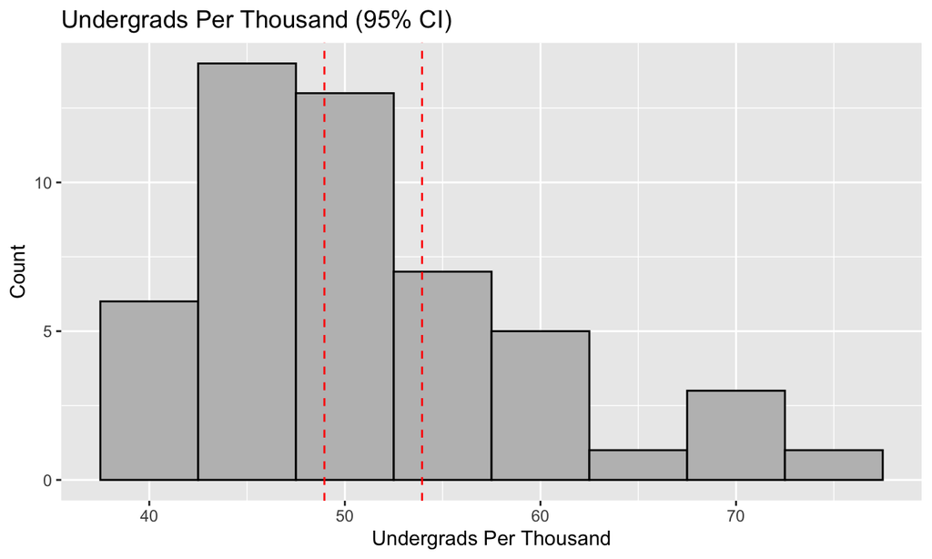

```r
ggplot(college, aes(x = UGradPerThou)) +
  geom_histogram(binwidth = 5, fill = "gray", color = "black") +
  geom_vline(xintercept = ci_ugpt, linetype = "dashed", color = "red") +
  labs(
    title = "Undergrads Per Thousand (95% CI)",
    x = "Undergrads Per Thousand",
    y = "Count"
  )
```

# 5 CI & t-test for `Undergrads`

**Step 1 — Point estimate.**

```r
mean(college$Undergrads, na.rm = TRUE)
```

```
#> [1] 302135.9
```

**Step 2 — One-sample *t*-test** ($H_0$: true mean $= 300{,}000$).

```r
t.test(college$Undergrads, mu = 300000)
```

```
#>
#>  One Sample t-test
#>
#> data:  college$Undergrads
#> t = 0.042133, df = 49, p-value = 0.9666
#> alternative hypothesis: true mean is not equal to 3e+05
#> 95 percent confidence interval:
#>  200262.8 404008.9
#> sample estimates:
#> mean of x
#>  302135.9
```

**Step 3 — Extract 95% CI bounds.**

```r
ci_ug <- t.test(college$Undergrads, conf.level = 0.95)$conf.int
ci_ug
```

```
#> [1] 200262.8 404008.9
#> attr(,"conf.level")
#> [1] 0.95
```

**Step 4 — Visualize.**

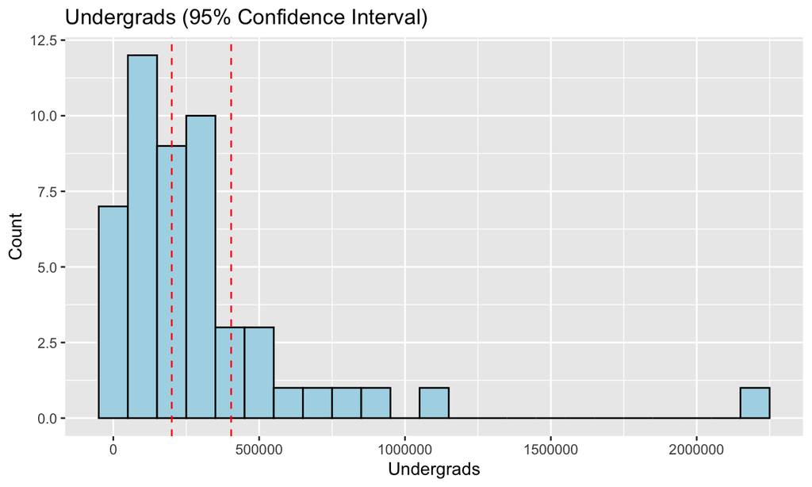

```r
ggplot(college, aes(x = Undergrads)) +
  geom_histogram(binwidth = 100000, fill = "lightblue", color = "black") +
  geom_vline(xintercept = ci_ug, linetype = "dashed", color = "red") +
  labs(
    title = "Undergrads (95% Confidence Interval)",
    x = "Undergrads",
    y = "Count"
  )
```

# 6 Quick Practice

**P1) Change the confidence level to 90% and 99% for `UGradPerThou`.** Compare how the interval widths change. Which one is the widest? Why?

```r
ci_90 <- t.test(college$UGradPerThou, conf.level = 0.90)$conf.int
ci_99 <- t.test(college$UGradPerThou, conf.level = 0.99)$conf.int
ci_90
```

```
#> [1] 49.36792 53.53440
#> attr(,"conf.level")
#> [1] 0.9
```

```r
ci_99
```

```
#> [1] 48.12111 54.78120
#> attr(,"conf.level")
#> [1] 0.99
```

**P2) Run a 95% CI for `Population` and plot the histogram** with dashed red lines for the lower and upper CI bounds.

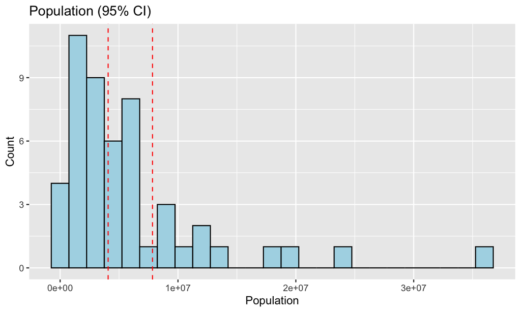

```r
ci_pop <- t.test(college$Population, conf.level = 0.95)$conf.int

ggplot(college, aes(x = Population)) +
  geom_histogram(binwidth = 1500000, fill = "lightblue", color = "black") +
  geom_vline(xintercept = ci_pop, linetype = "dashed", color = "red") +
  labs(
    title = "Population (95% CI)",
    x = "Population",
    y = "Count"
  )
```

**P3) Compare one-sample *t*-tests for `UGradPerThou` using different null values** (50 vs. 60). Report the test statistic, *p*-value, and conclusion for each. Which null hypothesis is more likely to be rejected?

```r
t.test(college$UGradPerThou, mu = 60)
```

```
#>
#>  One Sample t-test
#>
#> data:  college$UGradPerThou
#> t = -6.8799, df = 49, p-value = 1.018e-08
#> alternative hypothesis: true mean is not equal to 60
#> 95 percent confidence interval:
#>  48.95411 53.94821
#> sample estimates:
#> mean of x
#>  51.45116
```

```r
t.test(college$UGradPerThou, mu = 50)
```

```
#>
#>  One Sample t-test
#>
#> data:  college$UGradPerThou
#> t = 1.1679, df = 49, p-value = 0.2485
#> alternative hypothesis: true mean is not equal to 50
#> 95 percent confidence interval:
#>  48.95411 53.94821
#> sample estimates:
#> mean of x
#>  51.45116
```

# 7 Wrap-up

**Key takeaways**

- Use `t.test(x, conf.level = ...)` for a CI; `t.test(x, mu = ...)` for a one-sample test.
- Extract the CI with `$conf.int`, then draw vertical lines on histograms.
- Always check coercion to numeric and NA counts **before** inference.
- Wider CIs correspond to higher confidence levels.
- Smaller *p*-values give stronger evidence against $H_0$.
- Store intermediate results before using them in plots.